# AR Process Vignette

**Note:** Generative AI assistance was limited to generating plots from AR-process.R and integrating those plots into this R Markdown document. The R functions, roxygen documentation, and all other written content were developed independently and were not generated by AI.

This vignette demonstrates the three functions in the **AR-process.R** file for simulating and fitting Autoregressive (AR) time series models:

- `generate_ar_dgp()`: Simulates a stationary AR(m) time series
- `generate_user_ar()`: Simulates an AR(p) time series with user-supplied coefficients
- `fit_user_ar()`: Fits an AR(p) model via maximum likelihood

## Generating an AR(m) Data Generating Process

The `generate_ar_dgp()` function simulates a stationary AR(m) time series. If `phi` is not supplied, stationary AR coefficients are found via rejection sampling.

### Random Stationary AR(2)

By default, the function generates random stationary coefficients:

```r
set.seed(1)
dgp <- generate_ar_dgp(m = 2, variance = 2, n = 50, seed = 1)
```

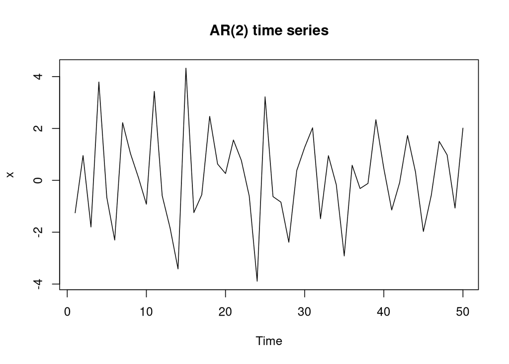

The function returns a list containing the time series `x` and the AR coefficients `phi` that were used:

```r
print(dgp$phi)
```

```
## [1] -0.4689827 -0.2557522
```

### User-Supplied Coefficients

You can also provide your own AR coefficients. This allows for non-stationary (explosive) processes:

```r
dgp2 <- generate_ar_dgp(m = 2, variance = 2, n = 50, seed = 1, phi = c(0.5, 0.3))
```

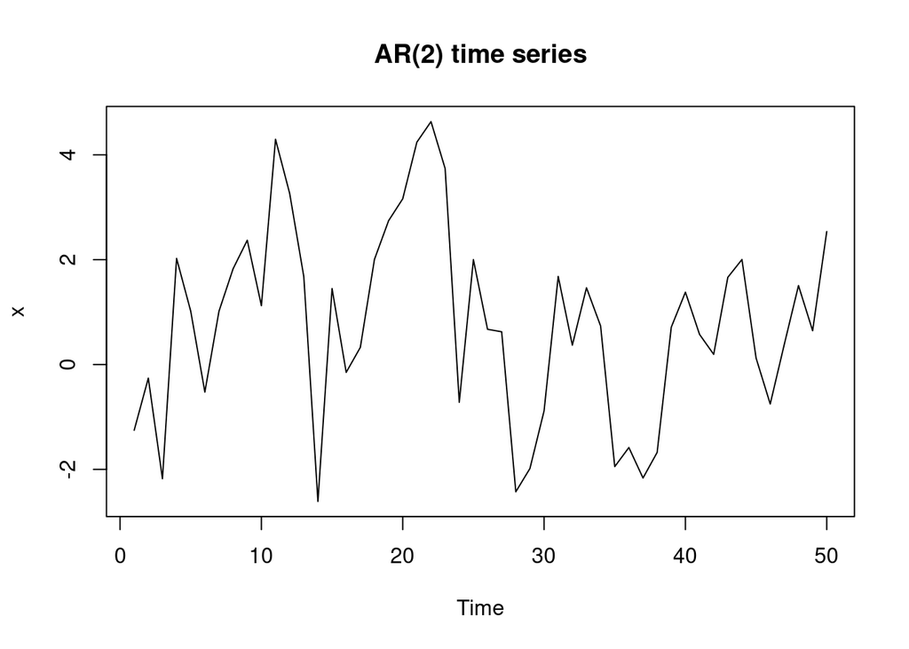

```r
print(dgp2$phi)
```

```
## [1] 0.5 0.3
```

## Generating a User-Specified AR(p) Time Series

The `generate_user_ar()` function simulates an AR(p) time series using user-supplied AR coefficients. No stationarity check is performed, so explosive processes are permitted.

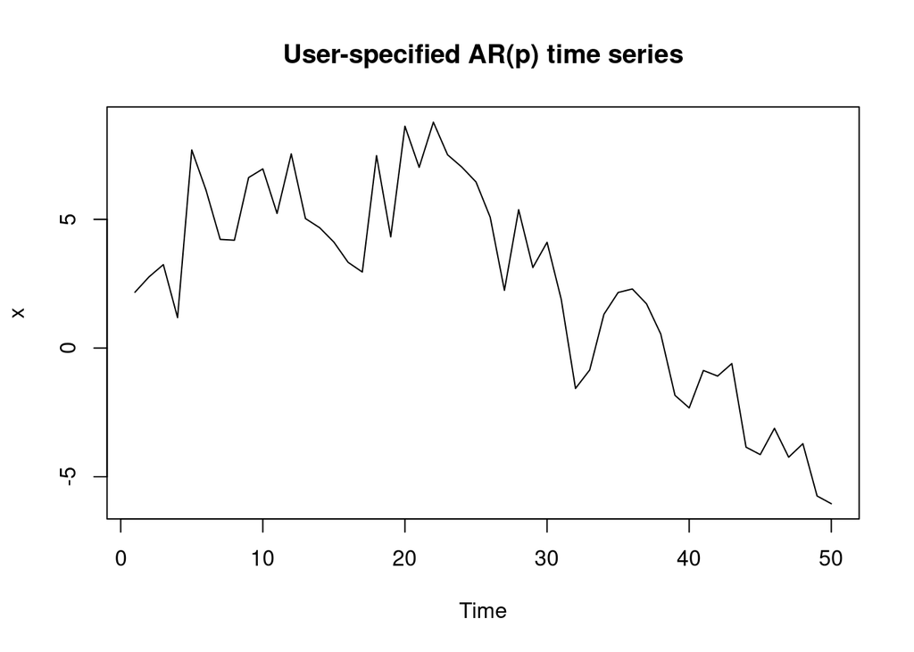

```r
x_user <- generate_user_ar(phi = c(0.5, 0.4), variance = 2, n = 50, seed = 9999)
plot(x_user, type = "l", xlab = "Time", ylab = "x",
     main = "User-specified AR(p) time series")
```

## Fitting an AR(p) Model to a DGP Series

The `fit_user_ar()` function fits an AR(p) model via maximum likelihood using `arima()` to the series stored in a DGP list object.

```r
dgp_fit <- generate_ar_dgp(m = 2, variance = 2, n = 100, seed = 42)
```

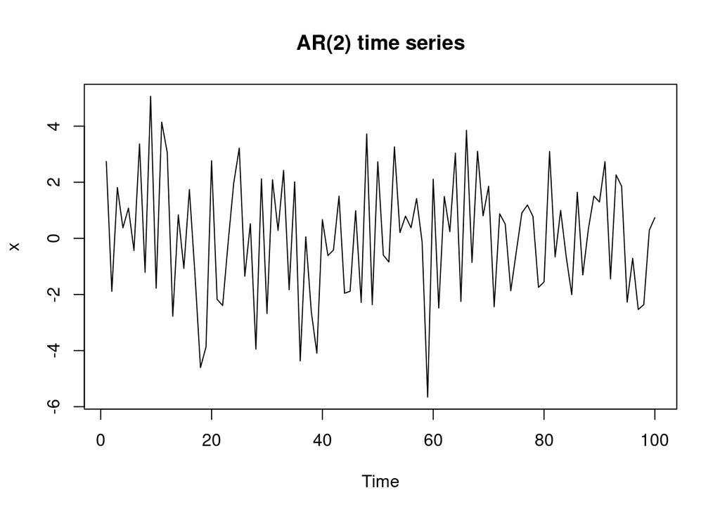

```r
result <- fit_user_ar(dgp_fit, p = 2)
```

### Model Summary

```r
print(result$fit)
```

```
##
## Call:
## arima(x = dgp$x, order = c(p, 0, 0), include.mean = FALSE)
##
## Coefficients:
##           ar1     ar2
##       -0.2163  0.2089
## s.e.   0.0976  0.0977
##
## sigma^2 estimated as 4.267:  log likelihood = -214.52,  aic = 435.05
```

### Coefficient Comparison

We can compare the true coefficients used in the DGP with the estimated coefficients from the fitted model:

```r
true_phi <- dgp_fit$phi
est_phi <- result$fit$coef

cat("True coefficients:", true_phi, "\n")
```

```
## True coefficients: -0.27677 0.2055073
```

```r
cat("Estimated coefficients:", est_phi, "\n")
```

```
## Estimated coefficients: -0.2162572 0.2088568
```

The estimated AR coefficients should be close to the true values used to generate the data.

## Summary

The AR-process.R file provides three functions for:

1. **Generating stationary AR processes** with automatic stationarity enforcement (`generate_ar_dgp`)
2. **Generating AR processes with custom coefficients** (`generate_user_ar`)
3. **Fitting AR models** to simulated or observed time series (`fit_user_ar`)

These functions are useful for simulation studies and for understanding the properties of AR time series models.

## References

Rizzo, Maria L. (2007). *Statistical Computing with R*. CRC Press.

Douglas, Alex. An Introduction to R. Retrieved from https://intro2r.com/

Wickham, Hadley. (2019). *Advanced R* (2nd ed.). Chapman and Hall/CRC. Retrieved from https://adv-r.hadley.nz/

Nosedal Sanchez, Alvaro. (2025). *AR(1) and AR(2) models*. University of Toronto lecture slides.